# Severe Weather Events With the Greatest Impact On Human Health and Economics from 1950 - 2011

## Synopsis

In this report, we investigate which types of severe weather events have the greatest impact on Human Health (defined by the number of injuries and fatalities) and Economics (defined by the total of property and crop damage). Our source of data is Severe Storm Data maintained by the National Weather Service, from 1950 - 2011. Our analysis concludes that **Tornados** cause the majority of human health impacts, accounting for approximately **62.30%** of total casualties. We also conclude that **Floods** cause the most economic damage, represent approximately **26.38%** of total storm related damage.

## Data Processing

The data for this study is information collected by the National Weather Service about damage and injuries associated with Storms and other weather related events in the United States, for the period of 1950 - 2011. The study data is captured in .csv formatted, compressed to save space.

### Inflation Calculations and Helper Functions

We start by referencing the following website to determine the cumulative inflation from 1950 to 2011. http://inflationdata.com/Inflation/Inflation_Calculators/Inflation_Rate_Calculator.asp.  
Using the included calculator, we determine that **$1.00** in 1950 is equivalent to **$9.33** in 2011. That implies an average inflation rate of:

```r
d2011 <- 9.33
d1950 <- 1.00
yrs <- 2011-1950
inflation <- (d2011/d1950)^(1/yrs) - 1
inflation
```

```
## [1] 0.03728882
```

We then define a helper function that will be used to scale numeric damage values in the dataset, based on a separate magnitude indicator column, adjusted for inflation.

```r
# Return a muliplier based on the magnitude of a damage value, adjusted for inflation
df <- function (e,eyear,inf) {
  if (is.null(e) || is.na(e))  f <-1
  else if (e %in% c("K","k")) f <- 1e3
  else if (e %in% c("M","m")) f <- 1e6
  else if (e %in% c("B","b")) f <- 1e9
  else f <- 1
  f * (1+inf)^(2011-eyear)
  }

dfv <- Vectorize(df)
```

### Reading in the Data

With these two components defined, we then read the entire compressed .csv file in native format.

```r
data <- read.csv("./data/repdata_data_StormData.csv.bz2",as.is=TRUE)
```

Performing some basic examinations of the data, we see there are 902297 rows in the dataset and 37 columns:

```r
dim(data)
```

```
## [1] 902297     37
```

```r
head(data[,1:10])
```

```
##   STATE__           BGN_DATE BGN_TIME TIME_ZONE COUNTY COUNTYNAME STATE
## 1       1  4/18/1950 0:00:00     0130       CST     97     MOBILE    AL
## 2       1  4/18/1950 0:00:00     0145       CST      3    BALDWIN    AL
## 3       1  2/20/1951 0:00:00     1600       CST     57    FAYETTE    AL
## 4       1   6/8/1951 0:00:00     0900       CST     89    MADISON    AL
## 5       1 11/15/1951 0:00:00     1500       CST     43    CULLMAN    AL
## 6       1 11/15/1951 0:00:00     2000       CST     77 LAUDERDALE    AL
##    EVTYPE BGN_RANGE BGN_AZI
## 1 TORNADO         0
## 2 TORNADO         0
## 3 TORNADO         0
## 4 TORNADO         0
## 5 TORNADO         0
## 6 TORNADO         0
```

### Extracting Relevant Data

For this study, we are only interested in the damage (property and crop) and casualties (fatalities and injuries) caused by the various storm events. This is represented by the columns: EVTYPE,BGN_DATE,FATALITIES,INJURIES,PROPDMG,PROPDMGEXP,CROPDMG,CROPDMGEXP).

We then extract only those columns of the data that we are interested in, keeping all observations in the file, and create three additional computational columns that indicate  
1. A calculation of the total *damage*, defined as *property damage + crop damage*, with individual row values normalized based on the scale represented in *PROPDMGEXP* and *CROPDMGEXP*  
2. A calculation of the total *casualties*, defined as *fatalities + injuries*  
3. A column representing the year of a given storm.

```r
library(dplyr)
library(lubridate)
```

```r
dataSubset <- tbl_df(data)
dataSubset <- select(dataSubset,REFNUM,EVTYPE,BGN_DATE,FATALITIES,INJURIES,
                     PROPDMG,PROPDMGEXP,CROPDMG,CROPDMGEXP)
dataSubset$year <- year(mdy_hms(dataSubset$BGN_DATE))
dataSubset$damage <-
  (dataSubset$PROPDMG * dfv(dataSubset$PROPDMGEXP,dataSubset$year,inflation)) +
  + (dataSubset$CROPDMG * dfv(dataSubset$CROPDMGEXP,dataSubset$year,inflation))
dataSubset$casualties <- dataSubset$FATALITIES + dataSubset$INJURIES
```

### Subset Data Summary

Looking at the subset data, we see

```r
summary(dataSubset)
```

```
##      REFNUM          EVTYPE            BGN_DATE           FATALITIES
##  Min.   :     1   Length:902297      Length:902297      Min.   :  0.0000
##  1st Qu.:225575   Class :character   Class :character   1st Qu.:  0.0000
##  Median :451149   Mode  :character   Mode  :character   Median :  0.0000
##  Mean   :451149                                         Mean   :  0.0168
##  3rd Qu.:676723                                         3rd Qu.:  0.0000
##  Max.   :902297                                         Max.   :583.0000
##     INJURIES            PROPDMG         PROPDMGEXP
##  Min.   :   0.0000   Min.   :   0.00   Length:902297
##  1st Qu.:   0.0000   1st Qu.:   0.00   Class :character
##  Median :   0.0000   Median :   0.00   Mode  :character
##  Mean   :   0.1557   Mean   :  12.06
##  3rd Qu.:   0.0000   3rd Qu.:   0.50
##  Max.   :1700.0000   Max.   :5000.00
##     CROPDMG         CROPDMGEXP             year          damage
##  Min.   :  0.000   Length:902297      Min.   :1950   Min.   :0.000e+00
##  1st Qu.:  0.000   Class :character   1st Qu.:1995   1st Qu.:0.000e+00
##  Median :  0.000   Mode  :character   Median :2002   Median :0.000e+00
##  Mean   :  1.527                      Mean   :1999   Mean   :7.743e+05
##  3rd Qu.:  0.000                      3rd Qu.:2007   3rd Qu.:1.076e+03
##  Max.   :990.000                      Max.   :2011   Max.   :1.381e+11
##    casualties
##  Min.   :   0.0000
##  1st Qu.:   0.0000
##  Median :   0.0000
##  Mean   :   0.1725
##  3rd Qu.:   0.0000
##  Max.   :1742.0000
```

```r
unique(dataSubset$year)
```

```
##  [1] 1950 1951 1952 1953 1954 1955 1956 1957 1958 1959 1960 1961 1962 1963
## [15] 1964 1965 1966 1967 1968 1969 1970 1971 1972 1973 1974 1975 1976 1977
## [29] 1978 1979 1980 1981 1982 1983 1984 1985 1986 1987 1988 1989 1990 1991
## [43] 1992 1995 1994 1993 1996 1997 1998 1999 2000 2001 2002 2003 2004 2005
## [57] 2006 2007 2008 2009 2010 2011
```

```r
head(dataSubset)
```

```
## Source: local data frame [6 x 12]
##
##   REFNUM  EVTYPE           BGN_DATE FATALITIES INJURIES PROPDMG PROPDMGEXP
## 1      1 TORNADO  4/18/1950 0:00:00          0       15    25.0          K
## 2      2 TORNADO  4/18/1950 0:00:00          0        0     2.5          K
## 3      3 TORNADO  2/20/1951 0:00:00          0        2    25.0          K
## 4      4 TORNADO   6/8/1951 0:00:00          0        2     2.5          K
## 5      5 TORNADO 11/15/1951 0:00:00          0        2     2.5          K
## 6      6 TORNADO 11/15/1951 0:00:00          0        6     2.5          K
## Variables not shown: CROPDMG (dbl), CROPDMGEXP (chr), year (dbl), damage
##   (dbl), casualties (dbl)
```

## Results

The goal of this investigation is to determine which types of storms have the most impact on Human Health and the greatest economic consequences, across the United States, over the entire period of time covered by the data captured.

### Common Grouping of the Data

We begin our analysis by defining economic consequence as the damage (property damage + crop damage) caused by the storm. Similarly, we define the Human Health impact as the casualties (fatalities + injuries) caused by the storm.

As a starting point to our investigations, we calculate the total damage and total casualties caused by each type of Storm Event (EVTYPE).

```r
rd2 <- dataSubset %>%
  group_by(EVTYPE) %>%
  summarize(damage=sum(damage),casualties=sum(casualties))
```

### Question One: Across the United States, which types of events are most harmful with respect to population health?

To investigate our first question, we start by sorting the storm data in descending order of storm casualties then calculate the percent of total and cumulative percent of total represented by the various storm event types.

```r
rd3 <- rd2 %>%
  arrange(desc(casualties))

tc <- sum(rd3$casualties)
rd3$pct <- rd3$casualties/tc * 100
rd3$cpct <- cumsum(rd3$pct)
rd4 <- filter(rd3,cpct<=95)
```

Looking at the results, we see that **TORNADO** type storms caused the greatest number of casualties across the US for the years included in the dataset, representing **62.3 percent** of the total casualties. The table and chart below show the storm types that represent approximately **95%** of the total casualties, sorted in descending order of total casualties over the years contained in the data:

```r
rd4
```

```
## Source: local data frame [21 x 5]
##
##                EVTYPE       damage casualties        pct     cpct
## 1             TORNADO 1.404025e+11      96979 62.2966089 62.29661
## 2      EXCESSIVE HEAT 6.017007e+08       8428  5.4139125 67.71052
## 3           TSTM WIND 7.495374e+09       7461  4.7927386 72.50326
## 4               FLOOD 1.842612e+11       7259  4.6629795 77.16624
## 5           LIGHTNING 1.326586e+09       6046  3.8837820 81.05002
## 6                HEAT 7.231886e+08       3037  1.9508842 83.00091
## 7         FLASH FLOOD 2.349961e+10       2755  1.7697353 84.77064
## 8           ICE STORM 1.501898e+10       2064  1.3258561 86.09650
## 9   THUNDERSTORM WIND 4.317750e+09       1621  1.0412853 87.13778
## 10       WINTER STORM 1.188050e+10       1527  0.9809023 88.11868
## 11          HIGH WIND 7.601089e+09       1385  0.8896854 89.00837
## 12               HAIL 2.514428e+10       1376  0.8839041 89.89227
## 13  HURRICANE/TYPHOON 9.058024e+10       1339  0.8601363 90.75241
## 14         HEAVY SNOW 1.750725e+09       1148  0.7374432 91.48985
## 15           WILDFIRE 6.168669e+09        986  0.6333789 92.12323
## 16 THUNDERSTORM WINDS 3.568796e+09        972  0.6243857 92.74762
## 17           BLIZZARD 1.302972e+09        906  0.5819892 93.32961
## 18                FOG 2.006191e+07        796  0.5113282 93.84094
## 19        RIP CURRENT 1.075968e+03        600  0.3854233 94.22636
## 20   WILD/FOREST FIRE 4.714607e+09        557  0.3578013 94.58416
## 21       RIP CURRENTS 2.286560e+05        501  0.3218284 94.90599
```

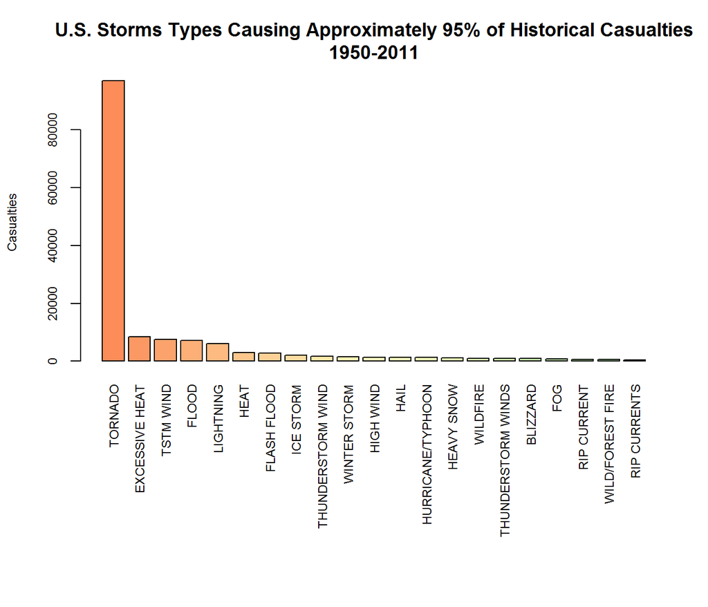

```r
library(RColorBrewer)
cols <- brewer.pal(3,"Spectral")
pal <- colorRampPalette(cols)
par(ps = 9, cex = 1, cex.main = 1, mar = c(12,4,4,2))
barplot(rd4$casualties,names.arg = rd4$EVTYPE,las=3,col=pal(nrow(rd4)),
        ylab="Casualties")
title(main="U.S. Storms Types Causing Approximately 95% of Historical Casualties\n1950-2011", cex.main=1.5)
```

### Question Two: Across the United States, which types of events have the greatest economic consequences?

To investigate our second question, we start by sorting the storm data in descending order of storm damage then calculate the percent of total and cumulative percent of total represented by the various storm event types.

```r
# Damage
rd5 <- rd2 %>%
  arrange(desc(damage))

td <- sum(rd5$damage)
rd5$pct <- rd5$damage/td * 100
rd5$cpct <- cumsum(rd5$pct)
rd6 <- filter(rd5,cpct<=95)
```

Looking at the results, we see that **FLOOD** type storms caused the greatest damage across the US for the years included in the dataset, representing **26.38 percent** of the total Storm Damage. The table and chart below show the storm types that represent **95%** of the total Storm damage, sorted in descending order of total damage over the years contained in the data:

```r
rd6
```

```
## Source: local data frame [19 x 5]
##
##                       EVTYPE       damage casualties        pct     cpct
## 1                      FLOOD 184261182735       7259 26.3750748 26.37507
## 2                    TORNADO 140402536747      96979 20.0971651 46.47224
## 3          HURRICANE/TYPHOON  90580241710       1339 12.9656209 59.43786
## 4                STORM SURGE  54073971540         51  7.7401275 67.17799
## 5                       HAIL  25144282032       1376  3.5991429 70.77713
## 6                FLASH FLOOD  23499605689       2755  3.3637245 74.14086
## 7                  HURRICANE  21933329065        107  3.1395283 77.28038
## 8                    DROUGHT  21604542837          4  3.0924659 80.37285
## 9                RIVER FLOOD  19600249306          4  2.8055721 83.17842
## 10                 ICE STORM  15018982122       2064  2.1498113 85.32823
## 11              WINTER STORM  11880503258       1527  1.7005707 87.02880
## 12            TROPICAL STORM  11828614034        398  1.6931433 88.72195
## 13                 HIGH WIND   7601088612       1385  1.0880169 89.80996
## 14                 TSTM WIND   7495374060       7461  1.0728850 90.88285
## 15                  WILDFIRE   6168668863        986  0.8829809 91.76583
## 16            HURRICANE OPAL   5733728367          2  0.8207237 92.58655
## 17          STORM SURGE/TIDE   5176351792         16  0.7409410 93.32749
## 18          WILD/FOREST FIRE   4714607453        557  0.6748471 94.00234
## 19 HEAVY RAIN/SEVERE WEATHER   4490918709          0  0.6428284 94.64517
```

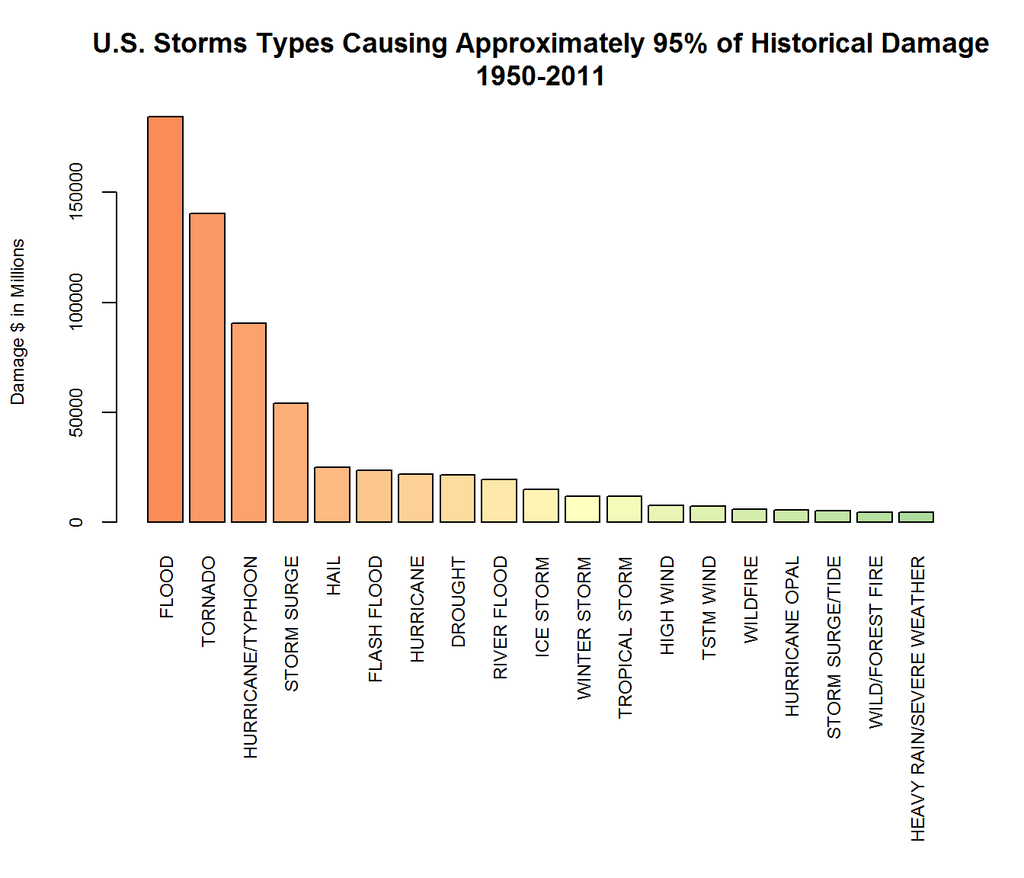

```r
library(RColorBrewer)
cols <- brewer.pal(3,"Spectral")
pal <- colorRampPalette(cols)
par(ps = 9, cex = 1, cex.main = 1, mar = c(12,4,4,2))
barplot(rd6$damage / 1e6,names.arg = rd6$EVTYPE,las=3,col=pal(nrow(rd4)),
        ylab="Damage $ in Millions")
title(main="U.S. Storms Types Causing Approximately 95% of Historical Damage\n1950-2011",
      cex.main=1.5)
```